# Learning Analytics Foundations Learning Lab 2

## Introduction

Building on the last learning lab in which we accessed data on the time students spent on the LMS across courses in five different subjects, in this learning lab, we’ll add a second data set to the mix. This data set is on the points students earned in the course.

In addition to joining together the two datasets (based on a common *key*), we’ll examine the relations between these two variables - time spent on the course and points earned.

## 1. PREPARE

### Packages 📦

We will load the same three data sets we loaded in the first learning lab: {tidyverse}, {janitor}, and {here}.

```r
library(tidyverse)
library(janitor)
library(here)
```

### Data

#### Data Source #2: Academic Achievement Data

In addition to the `time_spent` data we loaded We’ll explain a bit more about the second data set - on academic achievement data.

Academic achievement data is (obviously) is a very common form of data in education. In this learning lab, we’ll use both the sum of the points students earned as well as the number of points possible to compute the percentage of points they earned in the course—a measure comparable (but likely a little different based on teachers’ grading policies) to their final grade. We’ll use this in the second learning lab.

We’ll load the data in the same way as earlier:

```r
gradebook <- read_csv(here("data", "gradebook-summary.csv")) %>%
  clean_names()
```

You may choose to type the name of the gradebook into the console window and to then (like earlier) type enter/return to view a summary of what data this name points to.

We’ll also add the *wrangled* version of the data set we used in learning lab #1. This file should be saved in the data directory and is named “log-wrangled.csv”.

#### **Your Turn** **⤵**

Your turn! Using the code in the code chunk above as a starting point, modify `read_csv()` to read in the file “log-wrangled.csv”.

```r
log_wrangled <- read_csv(here("data", "log-wrangled.csv"))
```

In the environment tab of your RStudio Cloud window, you should now see the two data sets (gradebook and log_wrangled) loaded. If so, let’s proceed to the next steps. If you need any help, then reach out to us via Slack.

## 2. WRANGLE

If our goal is to join together these data sets to explore how the time spent on the course is related to the final grades achieved by students, then we need to take a few steps, first, to ensure that the files are ready to be joined. In particular, we’ll be:

1. Cleaning up the student ID variable in the log data
2. Processing the gradebook data
3. Joining the two data frame together into one data frame

Let’s take these in turn.

### Cleaning up the ID variable in the log data

To join two datasets, it is important that the *key* (or *keys*) on which you are joining the data is formatted identically. The key represents an identifier that is present in both of the data sets you are joining. For instance, you may have data collected from (or created about) the same students that are from two very different sources, such as a self-report survey of students and their teacher-assigned grades in class.

In the present case, we have gradebook data and data from the LMS on the time students spent on the course, but in one case—for the log data—the student identifier is formatted a bit differently. This is often the case, and to ensure that we can join together the two datasets into one, we’ll have to clean up the student_id variable, first. Let’s take a look at the log data by running the code in the chunk below.

```r
log_wrangled
```

| student_id | Subject | Semester | Section | gender | enrollment_reason | enrollment_status | time_spent | time_spent_hours |
| --- | --- | --- | --- | --- | --- | --- | --- | --- |
| _60186 | AnPhA | S116 | 01 | M | Course Unavailable at Local School | Approved/Enrolled | 2087.0501 | 3.478417e+01 |
| _66693 | AnPhA | S116 | 01 | M | Course Unavailable at Local School | Approved/Enrolled | 2309.0334 | 3.848389e+01 |
| _66811 | AnPhA | S116 | 01 | F | Course Unavailable at Local School | Approved/Enrolled | 5298.8507 | 8.831418e+01 |
| _66862 | AnPhA | S116 | 01 | F | Course Unavailable at Local School | Approved/Enrolled | 1746.9667 | 2.911611e+01 |
| _67508 | AnPhA | S116 | 01 | F | Scheduling Conflict | Approved/Enrolled | 2668.1830 | 4.446972e+01 |
| _70532 | AnPhA | S116 | 01 | F | Learning Preference of the Student | Approved/Enrolled | 2938.4666 | 4.897444e+01 |
| _77010 | AnPhA | S116 | 01 | F | Learning Preference of the Student | Approved/Enrolled | 1533.0996 | 2.555166e+01 |
| _85249 | AnPhA | S116 | 01 | F | Course Unavailable at Local School | Approved/Enrolled | 1209.8496 | 2.016416e+01 |
| _85411 | AnPhA | S116 | 01 | F | Scheduling Conflict | Approved/Enrolled | 473.0333 | 7.883888e+00 |
| _85583 | AnPhA | S116 | 01 | F | Scheduling Conflict | Approved/Enrolled | 5532.4164 | 9.220694e+01 |

[output cut: 706 more lines]

You may notice something is a bit different with this variable compared to the gradebook data - the student_id is prefaced with an underscore that the LMS happened to include.

We can remove these underscores using a technique in R for working with text - techniques we’ll explore in greater depth in a later module. For now, we’ll be using the `str_sub()` function (that is a part of the tidyverse). This function takes as input a string, or a word—or a variable with a string—and returns a subset of the word based on the position of the letters. There are lots of big ideas here, so let’s walk through an example.

Run the code below, in which we specify that we want the output to begin with the first letter of the string, and to end with the tenth letter. In other words, we want to return the entire word - something that is not useful just yet.

```r
str_sub("Task 1 %54", start = 1, end = 10)
```

```
## [1] "Task 1 %54"
```

Now, let’s imagine that our data erroneously included the characters “%54”, and that we wanted to remove those from our string so that what was returned was only the task and the number.

#### **Your Turn** **⤵**

Can you modify the code below so that the output returned is only the task and the number?

**Hint**: Try changing the values entered for the start and end arguments to the function.

```r
str_sub("Task 1 %54", start = 1, end = 6)
```

```
## [1] "Task 1"
```

A feature of str_sub is that it not only works for a single string, but also a collection of strings. Run the code below with the start and end values you entered above to clean up a collection— technically a vector created with the combine, or c(), function—of strings next.

```r
str_sub(c("Task 1 %54",
          "Task 2 %54",
          "Task 3 %54",
          "Task 4 %54",
          "Task 5 %54",
          "Task 6 %54",
          "Task 7 %54",
          "Task 8 %54",
          "Task 9 %54",
          "Task 10 %54"),
        start = 1, end = 6)
```

```
##  [1] "Task 1" "Task 2" "Task 3" "Task 4" "Task 5" "Task 6" "Task 7" "Task 8"
##  [9] "Task 9" "Task 1"
```

Detour complete! Let’s now consider how we can use what we did above to clean the student_id variable in the `log_wrangled` file.

In the code below, a template that returns the entire student ID is provided.

#### **Your Turn** **⤵**

How can you modify this code to remove the leading underscore? Note that in addition to using mutate to create a new version of our student_id variable, in the next line, we change the student_id variable to be an integer. This is because our ID variable in the other data set is an integer, and variables not only need to be named identically but also need to be the same data type in order to be joined together.

**Hint**: Like above, consider changing the start and end values.

```r
log_wrangled %>%
  mutate(student_id = str_sub(student_id, start = 2, end = 7)) %>%
  mutate(student_id = as.integer(student_id))
```

| student_id | Subject | Semester | Section | gender | enrollment_reason | enrollment_status | time_spent | time_spent_hours |
| --- | --- | --- | --- | --- | --- | --- | --- | --- |
| 60186 | AnPhA | S116 | 01 | M | Course Unavailable at Local School | Approved/Enrolled | 2087.0501 | 3.478417e+01 |
| 66693 | AnPhA | S116 | 01 | M | Course Unavailable at Local School | Approved/Enrolled | 2309.0334 | 3.848389e+01 |
| 66811 | AnPhA | S116 | 01 | F | Course Unavailable at Local School | Approved/Enrolled | 5298.8507 | 8.831418e+01 |
| 66862 | AnPhA | S116 | 01 | F | Course Unavailable at Local School | Approved/Enrolled | 1746.9667 | 2.911611e+01 |
| 67508 | AnPhA | S116 | 01 | F | Scheduling Conflict | Approved/Enrolled | 2668.1830 | 4.446972e+01 |
| 70532 | AnPhA | S116 | 01 | F | Learning Preference of the Student | Approved/Enrolled | 2938.4666 | 4.897444e+01 |
| 77010 | AnPhA | S116 | 01 | F | Learning Preference of the Student | Approved/Enrolled | 1533.0996 | 2.555166e+01 |
| 85249 | AnPhA | S116 | 01 | F | Course Unavailable at Local School | Approved/Enrolled | 1209.8496 | 2.016416e+01 |
| 85411 | AnPhA | S116 | 01 | F | Scheduling Conflict | Approved/Enrolled | 473.0333 | 7.883888e+00 |
| 85583 | AnPhA | S116 | 01 | F | Scheduling Conflict | Approved/Enrolled | 5532.4164 | 9.220694e+01 |

[output cut: 706 more lines]

Note that a bit different from in the example above, here we are using str_sub() *within* a mutate function. In other words, whereas earlier we cleaned a vector of strings (consisting of ten strings for Tasks 1-10), in the code above, we’re still using str_sub() with a vector, but it is a vector representing *all* of the student_id variables in our `log_wrangled`.

Whereas the above code printed the output for you to view, the code below assigns—saves— the output to `log_wrangled`, such that when you use that data file in subsequent steps, the changes you made will be reflected. In other words, the student_id variable will be cleaned and ready to go for the next steps.

#### **Your Turn** **⤵**

Below, make the same change to the start and/or end values you made in the previous chunk and then run the chunk.

```r
log_wrangled <- log_wrangled %>%
  mutate(student_id = str_sub(student_id, start = 2, end = 7)) %>%
  mutate(student_id = as.integer(student_id))
```

### Processing the gradebook data

In the previous step, we further processed the log data. In this step, we’ll process the gradebook data. In particular, we’ll separate the `course_id` variable in the same way we separated that variable in the log data, and we’ll also calculate a new variable representing the proportion of points students earned (out of the points possible to earn).

Let’s start with separating the `course_id` variable. Run the code in the next chunk to do this. If you named the three parts of the course ID differently than they’re named below (and saved the data you processed to use in this learning lab), be sure that these three variables are named identically; this is the *key* (pun intended!) to these variables joining correctly.

```r
gradebook <- gradebook %>%
  separate(course_id,
           c("Subject", "Semester", "Section"))
```

Next, we’ll mutate our data set to create a new column, one representing the proportion of points students earned. Let’s consider a data frame with example data, `df4` .

```r
df4 <- tibble(var_a = c(8, 8, 7, 8, 9, 6, 8, 8, 7, 8),
              var_b = 9)
```

*Note*: To create `df4`, for `var_a`, we passed a *vector* that we created with the function `c()` that contains 10 values. Consider these to be the number of times that learners participated in an outside-of-school STEM club. Instead of passing another vector for `var_b`, we simply used the value 9, which represents the number of opportunities students had to participate in the outside-of–school STEM club . In this case, the value 9 is repeated for however many rows there are in the data frame. Thus, in the context of creating a data frame, `var_b = 9` is the same as `var_b = c(9, 9, 9, 9, 9, 9, 9, 9, 9, 9)`.

Since interpreting proportions when the denominator is nine can be difficult, we may which to create a variable for the proportion.

#### **Your Turn** **⤵**

After running the chunk above, print `df4` to the console to get a sense of what the data frame consists of. To create a third variable that represents the proportion of STEM club activities students participated in, divide `var_a` by `var_b`.

```r
df4 <- df4 %>%
  mutate(var_a / var_b)
```

**Hint**: Take a peak at your work on the last learning lab as an example.

What happens if the output is different than you intended? That’s no problem! Re-run the code-chunk *above* (in which we create `df`) to have a blank slate with which to try again.

#### **Your Turn** **⤵**

Your turn once more. This time, create a new variable—here, let’s name it `proportion_earned`—using the `gradebook` data. This will involve using the mutate function with the `gradebook` data, creating a new variable (`proportion_earned`) on the basis of the values of two existing variables:

- `total_points_possible`
- `total_points_earned`

Also, once your code is ready, you’ll need to assign the results back to `gradebook`. This is challenging as you’re starting from scratch with the code. However, good R programmers use other code (that they or others wrote!) often, so feel free to copy and paste code from other, similar problems to give yourself a head start.

```r
gradebook <- gradebook %>%
  mutate(proportion_earned = total_points_earned / total_points_possible)
```

Once the above step is complete, take another look at `gradebook` by printing it to the console. There should now be seven columns, the six originally in the data and a new, seventh variable you’ve mutated.

### Joining the data

We’re now ready to join! At their core, joins involve operations on two data frames at the same time. This may seem useful only in certain cases, but consider the following data analysis tasks:

- You have collected data from *students* from one of ten classrooms; at the same time, you have data on the *teachers* of those ten classes (five of which tried out a new curriculum, and five who taught a “business-as-usual” curriculum
- You are studying the posts on *Twitter* and *Pinterest* of one of around 100 mathematics teachers
- After working with a local school district, you collected survey responses from 100s of *teachers* who teach in one of approximately 25 elementary, middle, and high *schools*; you received data from the district on the characteristics of the schools, including how many students they serve and how many teachers work in them

In each of these cases—and many others like them—your single analysis involves multiple data files. While in some cases it is possible to analyze each data set individually, it is often useful (or necessary, depending upon your goal) to join these sources of data together. This is especially the case for learning analytics research, in which researchers and analysts often are interested in understanding teaching and learning through the lens of multiple data sources, including digital data, institutional records, and survey data, among other sources. In all of these cases, knowing how to promptly join together files—even files with tens of thousands of hundreds of thousands of rows—can be empowering.

Enough on the magic and beauty of joins; let’s try a few out!

Run the code below and then type `df5` and `df6` in the console.

```r
df5 <- tibble(name = c("Sheila", "Tayla", "Marcus"),
              n_stem_classes = c(4, 5, 6))

df6 <- tibble(name = c("Tayla", "Marcus", "Sheila", "Vin"),
              interest_in_stem = c(4, 7, 6, 6))
```

While some of the time it takes some thought to determine what the key is (or what the keys are—you can join on multiple keys!), in the above case, there is just one variable that meets both of the above characteristics.

#### **Your Turn** **⤵**

In the code below, enter the name of the variable that is the key within the quotation marks following `by =`. Then run the code chunk and note the output.

```r
full_join(df5, df6, by = "name")
```

| name | n_stem_classes | interest_in_stem |
| --- | --- | --- |
| Sheila | 4 | 6 |
| Tayla | 5 | 4 |
| Marcus | 6 | 7 |
| Vin | NA | 6 |

What do you notice about the output of the `full_join()`? All observations are valid; consider how the output is similar to and different from `df5` and `df6`, particularly in one or more notes following the bullet point.

`full_join()` is one of a number of joins from which we can choose. `full_join()` is distinguished from the other joins by how it returns *all* of the rows in both of the data frames being joined. If a particular key is present in one of the data frames but not the other, the values for the variable in the data set for which the key is not present are simply recorded as missing (like in the above, where there is no value for the number of STEM classes Vin has taken).

There is one other join on which we’ll focus for now. That is `left_join()`, which differs from `full_join()` in that it returns all of the rows in the “left” data frame, the data frame named first in the function, but not all of the rows in the “right” data frame: it retains only the rows in the “right” data frame, the data frame named second in the function, that have a matching key. An example is necessary. Before running the code below, add the same key you added above.

#### **Your Turn** **⤵**

```r
left_join(df5, df6, by = "name")
```

| name | n_stem_classes | interest_in_stem |
| --- | --- | --- |
| Sheila | 4 | 6 |
| Tayla | 5 | 4 |
| Marcus | 6 | 7 |

Different from the above, `left_join()` did not return all of the rows from both data frames, instead returning *all* of the rows in the “left” data frame (and those in the “right” data frame with a match).

For now, we’re going to use a single join function, `full_join()`. In the code below, join `gradebook` and `log_wrangled`; type the names of those two data frames as arguments to the `full_join()` function in a similar manner as in the `full_join()` code above, and then run this code chunk. For now, don’t specify anything for the `by =` part of the function.

```r
# join together the gradebook and log_wrangled
joined_data <- full_join(gradebook, log_wrangled)
joined_data
```

| student_id | Subject | Semester | Section | total_points_possible | total_points_earned | proportion_earned | gender | enrollment_reason | enrollment_status | time_spent | time_spent_hours |
| --- | --- | --- | --- | --- | --- | --- | --- | --- | --- | --- | --- |
| 43146 | FrScA | S216 | 02 | 1217 | 1150.0000 | 0.944946590 | F | Course Unavailable at Local School | Approved/Enrolled | 1555.1667 | 2.591944e+01 |
| 44638 | OcnA | S116 | 01 | 1676 | 1384.2300 | 0.825912888 | M | Course Unavailable at Local School | Approved/Enrolled | 1382.7001 | 2.304500e+01 |
| 47448 | FrScA | S216 | 01 | 1232 | 1116.0000 | 0.905844156 | F | Other | Approved/Enrolled | 860.4335 | 1.434056e+01 |
| 47979 | OcnA | S216 | 01 | 1833 | 1492.7300 | 0.814364430 | M | Course Unavailable at Local School | Approved/Enrolled | 1598.6166 | 2.664361e+01 |
| 48797 | PhysA | S116 | 01 | 2225 | 1994.7500 | 0.896516854 | M | Learning Preference of the Student | Approved/Enrolled | 1481.8000 | 2.469667e+01 |
| 51943 | FrScA | S216 | 03 | 1222 | 70.0000 | 0.057283142 | M | Learning Preference of the Student | Withdrawn | 3.4501 | 5.750167e-02 |
| 52326 | AnPhA | S216 | 01 | 1775 | 1518.5100 | 0.855498586 | F | Other | Approved/Enrolled | 1321.8164 | 2.203027e+01 |
| 52446 | PhysA | S116 | 01 | 2225 | 2198.0000 | 0.987865169 | F | Learning Preference of the Student | Approved/Enrolled | 1390.2167 | 2.317028e+01 |
| 53447 | FrScA | S116 | 01 | 1212 | 1173.0000 | 0.967821782 | F | Course Unavailable at Local School | Approved/Enrolled | 1479.4166 | 2.465694e+01 |
| 53475 | FrScA | S116 | 02 | 1212 | 0.0000 | 0.000000000 | F | Course Unavailable at Local School | Dropped | NA | NA |

[output cut: 820 more lines]

#### **Your Turn** **⤵**

In the code below, write your join like above, but add the `by = c("student_id", "Semester", "Subject", "Section")` part to your code. You may notice the red message you may have noticed does not appear. This is generally a better practice because you know precisely on which variables you data sets are joining.

```r
# join together the gradebook and log_wrangled
joined_data <- full_join(gradebook, log_wrangled, by = c("student_id", "Subject", "Semester", "Section"))

joined_data
```

| student_id | Subject | Semester | Section | total_points_possible | total_points_earned | proportion_earned | gender | enrollment_reason | enrollment_status | time_spent | time_spent_hours |
| --- | --- | --- | --- | --- | --- | --- | --- | --- | --- | --- | --- |
| 43146 | FrScA | S216 | 02 | 1217 | 1150.0000 | 0.944946590 | F | Course Unavailable at Local School | Approved/Enrolled | 1555.1667 | 2.591944e+01 |
| 44638 | OcnA | S116 | 01 | 1676 | 1384.2300 | 0.825912888 | M | Course Unavailable at Local School | Approved/Enrolled | 1382.7001 | 2.304500e+01 |
| 47448 | FrScA | S216 | 01 | 1232 | 1116.0000 | 0.905844156 | F | Other | Approved/Enrolled | 860.4335 | 1.434056e+01 |
| 47979 | OcnA | S216 | 01 | 1833 | 1492.7300 | 0.814364430 | M | Course Unavailable at Local School | Approved/Enrolled | 1598.6166 | 2.664361e+01 |
| 48797 | PhysA | S116 | 01 | 2225 | 1994.7500 | 0.896516854 | M | Learning Preference of the Student | Approved/Enrolled | 1481.8000 | 2.469667e+01 |
| 51943 | FrScA | S216 | 03 | 1222 | 70.0000 | 0.057283142 | M | Learning Preference of the Student | Withdrawn | 3.4501 | 5.750167e-02 |
| 52326 | AnPhA | S216 | 01 | 1775 | 1518.5100 | 0.855498586 | F | Other | Approved/Enrolled | 1321.8164 | 2.203027e+01 |
| 52446 | PhysA | S116 | 01 | 2225 | 2198.0000 | 0.987865169 | F | Learning Preference of the Student | Approved/Enrolled | 1390.2167 | 2.317028e+01 |
| 53447 | FrScA | S116 | 01 | 1212 | 1173.0000 | 0.967821782 | F | Course Unavailable at Local School | Approved/Enrolled | 1479.4166 | 2.465694e+01 |
| 53475 | FrScA | S116 | 02 | 1212 | 0.0000 | 0.000000000 | F | Course Unavailable at Local School | Dropped | NA | NA |

[output cut: 820 more lines]

**Hint:** If you’re curious about how to format the use of the `by =` part of your code, look up above at how you used this argument to the `full_join()` function.

What do you notice about the result—the data you joined? In particular, how does it differ from the two data sets from which it was created? Add one or more notes below.

## 3. EXPLORE

Having prepared both of the data sets we joined together, and worked hard to join those data sets, we’re now ready to use this joined data set in our exploration of how the time students spent on the course LMS relate to the number of points they earned throughout the course.

We’ll be using the {ggplot2} package again, but, this time, will be creating a different type of plot.

Run the code below to create a scatter plot of the proportion of points students earned and the number of hours they spent on the course LMS.

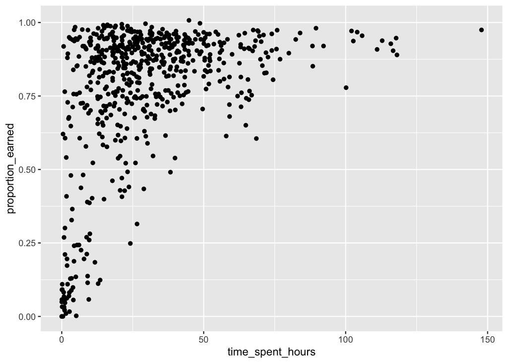

```r
ggplot(joined_data, aes(x = time_spent_hours, y = proportion_earned)) +
  geom_point()
```

What do you notice about this graph? And what do you wonder? How about the code—what do you notice about it (and what do you wonder)? Add one or more of what you see as the most important elements.

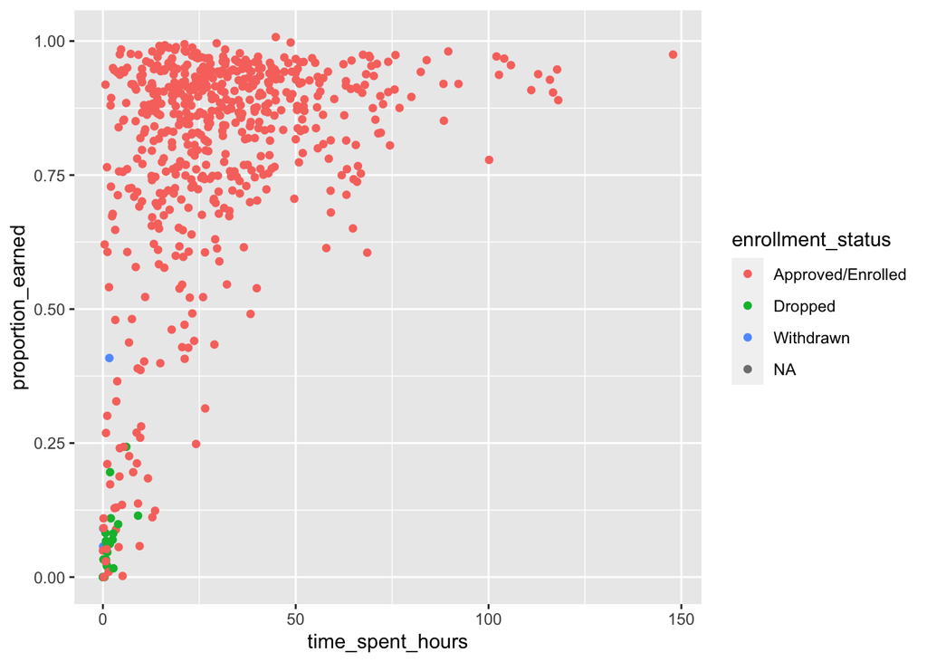

```r
ggplot(joined_data, aes(x = time_spent_hours, y = proportion_earned, color = enrollment_status)) +
  geom_point()
```

#### **Your Turn** **⤵**

We can also additionally create faceted plots, like the one you created in the last learning lab. In the code below, facet the plot by `Subject`.

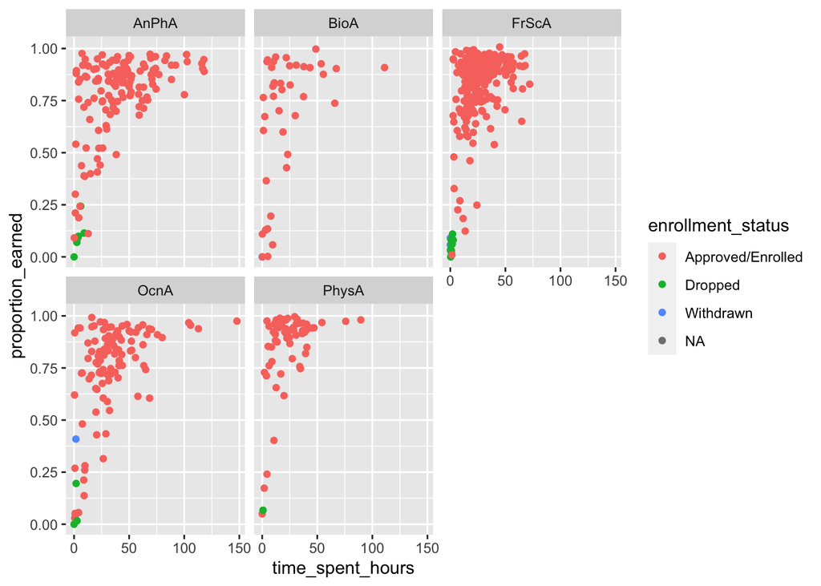

```r
ggplot(joined_data, aes(x = time_spent_hours, y = proportion_earned, color = enrollment_status)) +
  geom_point() +
  facet_wrap(~Subject)
```

**Hint**: Take a peak at the code you wrote for the first learning lab in which you created a faceted plot.

You may wish to style your plot. A few ways you can do that are as follows; we’ll discuss more throughout the institute. For each of the following, add them to your plot by adding a plus symbol to the line prior to the line you are adding. For instance, the following code styles the x-axis label of a plot:

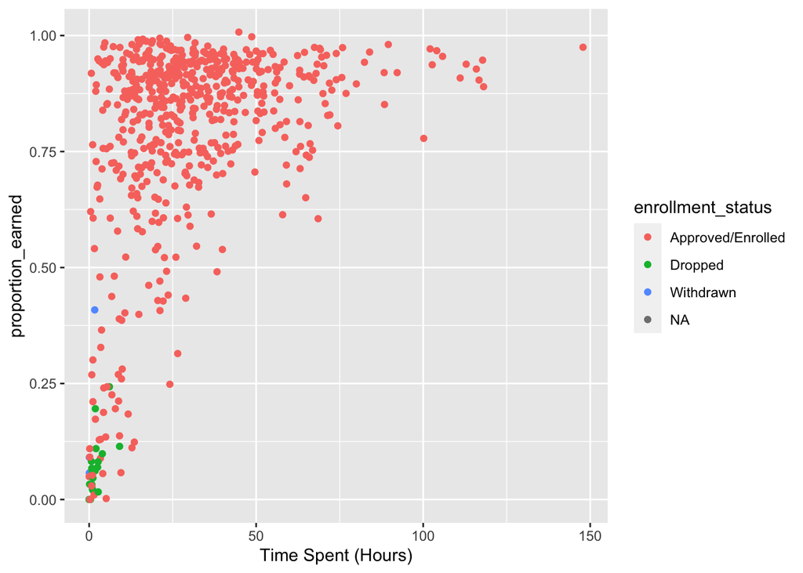

```r
ggplot(joined_data, aes(x = time_spent_hours, y = proportion_earned, color = enrollment_status)) +
  geom_point() +
  xlab("Time Spent (Hours)")
```

#### **Your Turn** **⤵**

Try adding (and modifying, if you’d like) any of the following to the faceted plot you created in the code chunk below:

- `xlab("Time Spent (Hours)")`
- `ylab("Proportion of Points Earned")`
- `scale_color_brewer("Enrollment Status", type = "qual", palette = 3)`
- `ggtitle("How Time Spent on Course LMS is Related to Points Earned in the Course")`
- `theme(legend.position = "bottom")`

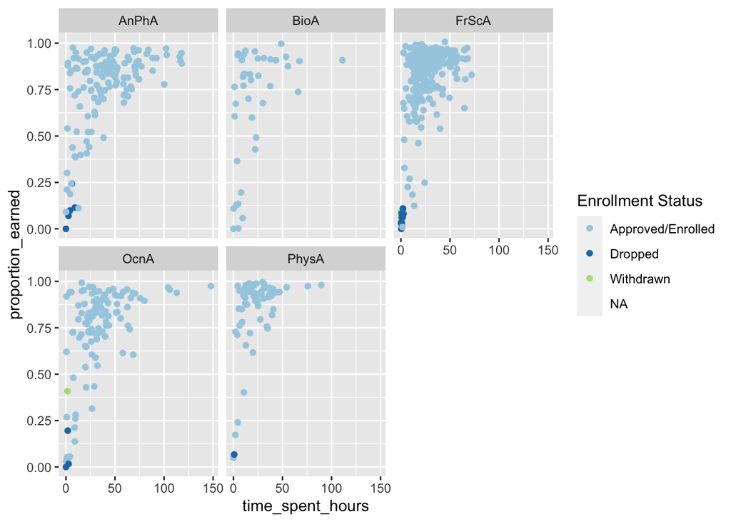

```r
ggplot(joined_data, aes(x = time_spent_hours, y = proportion_earned, color = enrollment_status)) +
  geom_point() +
  facet_wrap(~Subject) +
  scale_color_brewer("Enrollment Status", type = "qual", palette = 3)
```

Once you have settled on a plot you are happy with (for now!), add a sentence or two interpreting your graph (like you were describing it within a manuscript):

Last, if you want, you can save the processed data set to your data folder using `write_csv()`.

```r
write_csv(joined_data, here("data", "joined-data.csv"))
```

## 5. COMMUNICATE

In this learning lab, we covered a lot of ground, from extensively wrangling our data (further), joining together two data sets, and creating plots that depicted the relations between two variables. We also built on the ggplot’ting we began in the first learning lab, going deeper in terms of the the type of plot we created as well as how we styled it.

Like for the first learning lab, below, add a few notes in response to the prompts:

*One thing I took away from this learning lab*:

*One thing I want to learn more about*:

## Reach

For this learning lab, your reach is to join together two of your own data sets. Even if you don’t expand on this code here, gaining experience joining data sets with which you’re familiar can be handy. If you do this, re-knit your document when complete or at a stopping point so you have a record of your work!

If you do not have data you wish to join at this time, consider reading one of these resources on joining or that involve joining:

Relational Data from the excellent R for Data Science book: https://r4ds.had.co.nz/relational-data.html

Walkthrough 1: The Education Data Science Pipeline With Online Science Class Data from Data Science in Education Using Rhttps://datascienceineducation.com/c07.html